# Use OSM API overpass

Jan-Philipp Kolb

12/06/2015

# Introduction

- The package [osmar](http://cran.r-project.org/web/packages/osmar/index.html) provides good possibilities to download information about small areas from [OpenStreetMap](http://www.openstreetmap.org/).
- With the this [link](https://www.openstreetmap.org/export) it is possible to export data directly from OpenStreetMap.
- You will get [.osm](http://wiki.openstreetmap.org/wiki/OSM_XML)-data. See the [osmar-manual](http://osmar.r-forge.r-project.org/RJpreprint.pdf) to work with this data.

But Sometimes you might want to have information only on one [specific topic](http://www.r-bloggers.com/r-streets-of-france/) and you want that information for a [bigger area](https://help.openstreetmap.org/questions/34080/using-r-to-get-lat-and-lon-from-osm_ids-without-assistance-of-external-software-eg-qgis). In this case [osmar](http://journal.r-project.org/archive/2013-1/eugster-schlesinger.pdf) might not be the perfect solution.

# Download specific information

There are several ways to download information from OpenStreetMap. On of these possibilities is the mapquest Xapi Service:

http://open.mapquestapi.com/xapi/

To get information, you have to specify a bounding box:

[left,bottom,right,top]

- [Defining an adequate bounding box](http://gis.stackexchange.com/questions/46954/clip-spatial-object-to-bounding-box-in-r)

# Alternatives/Example to define bounding box

[left,bottom,right,top]

or:

[lon.min,lat.min,lon.max,lat.max]

for example Mannheim Seckenheim:

[8.5382,49.4573,8.5808,49.4759]

# Download Link

Links to download information from this section

(pubs in this case):

```r
"http://open.mapquestapi.com/xapi/api/0.6/node%5B
amenity=pub%5D%5Bbbox=8.5382,49.4573,8.5808,49.4759%5D"
```

# Using R to download information:

The library [XML](http://cran.r-project.org/web/packages/XML/index.html) is essential to perform the following steps:

```r
install.packages("XML")
library(XML)
```

Now the command xmlParse can be used to download information:

```r
ab <- xmlParse("http://open.mapquestapi.com/xapi/api/0.6/node%5B
               amenity=pub%5D%5Bbbox=-77.041579,38.885851,
               -77.007247,38.900881%5D")

bbox <- "-77.041579,38.885851,-77.007247,38.900881"
abc <- xmlParse(paste("http://open.mapquestapi.com/xapi/api/0.6/node%5B
                      amenity=pub%5D%5Bbbox=",
                      bbox,"%5D",sep=""))
```

# Finding a specific place

```r
library(ggmap)
  # lon - east west
  # lat - south north
MAcode1 <- geocode("Mannheim Sandhofen")
MAcode2 <- geocode("Mannheim Rheinau")

MAcode3 <- geocode("Mannheim Schloss")
MAcode4 <- geocode("Mannheim Wallstadt")

  # [left,bottom,right,top]
bbox2 <- paste(MAcode3$lon,MAcode2$lat,MAcode4$lon,MAcode1$lat,sep=",")
abcd <- xmlParse(paste("http://open.mapquestapi.com/xapi/api/0.6/node%5B
                       amenity=pub%5D%5Bbbox=",
                       bbox2,"%5D",sep=""))
```

# Getting a bounding box from administrative areas.

- [Adminstrative Areas](https://en.wikipedia.org/wiki/Administrative_division) from [GADM](http://www.gadm.org/).

```r
library(raster)
LUX3 <- getData('GADM', country='LUX', level=3)

LUXT <- LUX3[LUX3@data$NAME_3=="Troisvierges",]
```

```r
library(sp)
bLUXT <- bbox(LUXT)
bbox3 <- paste(bLUXT[1,1],bLUXT[2,1],bLUXT[1,2],bLUXT[2,2],sep=",")
abct <- xmlParse(paste("http://open.mapquestapi.com/xapi/api/0.6/node%5B
                       amenity=pub%5D%5Bbbox=",
                       bbox3,"%5D",sep=""))
```

# Available Map Features

An overview of the different map features is available on the [OSM wiki](http://wiki.openstreetmap.org/wiki/Map_Features).

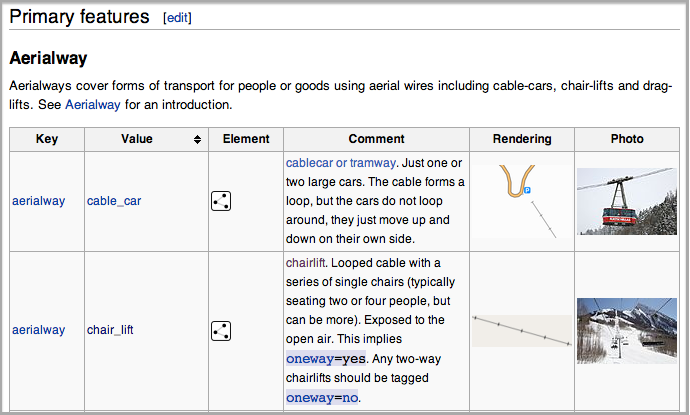

# Usage of overpass API

- An very good alternative for [xapi](http://wiki.openstreetmap.org/wiki/Xapi) is the [overpass API](http://wiki.openstreetmap.org/wiki/Overpass_API). [Here](http://wiki.openstreetmap.org/wiki/DE:Overpass_API/Beispielsammlung#Stra.C3.9Fenliste) are some use cases available.
- [Language Guide](http://wiki.openstreetmap.org/wiki/DE:Overpass_API/Language_Guide) and [convert form](http://overpass-api.de/convert_form.html)
- Here is the [query form](http://overpass-api.de/query_form.html)
- [Overpass-turbo](https://www.mapbox.com/guides/overpass-turbo/) is an alternative, but no API.
- OpenAlfaPlot on how to query Openstreetmap using the Overpass API.
- [About overpass API in German](http://podcast.openstreetmap.de/2012/12/28/osmde009-osm-talk-die-overpass-api/)
- An [example](http://statistik-stuttgart.de/r-osm-maps-with-osmar-and-the-overpass-x-api/) on how to use the [overpass API](http://wiki.openstreetmap.org/wiki/Overpass_API) with R.

# The overpass API

You can get all streets in Troisdorf with the following command:

```r
Troisdorf <- xmlParse("http://www.overpass-api.de/api/interpreter?data=
                      area[name=\"Troisdorf\"];
                      way(area)[highway][name];out;")
```

[Information on how to organise the command line.](http://overpass-api.de/command_line.html)

Example: Find all cinemas in Bonn which are at most 100m away from bus stops

```r
CinemasBonn <- xmlParse("http://www.overpass-api.de/api/interpreter?data=
                        area[name=\"Bonn\"];node(area)[highway=bus_stop];
                        node(around:100)[amenity=cinema];out;")
```

# All restaurants in Ilvesheim:

```r
rest_IH <- xmlParse("http://www.overpass-api.de/api/interpreter?data=
                                area[name=\"Ilvesheim\"];node(area)
                                [amenity=restaurant];out;")
```

In R We can use the powerful `osmar`-package:

```r
saveXML(rest_IH,file="rest_IH.XML")
library("osmar")
ilv <- get_osm(complete_file(), source = osmsource_file("rest_IH.XML"))

rest <- find(ilv, node(tags(k == "amenity")))

plot_nodes(ilv,col = "red")
```

# Find restaurants in Feudenheim (admin_level=9)

```r
rest_FD <- xmlParse("http://www.overpass-api.de/api/interpreter?data=
                                 area[name=\"Feudenheim\"];node(area)
                                 [amenity=restaurant];out;")
```

# Get the administrative boundaries for the city of Mannheim:

```r
boundaryMA <- xmlParse("http://www.overpass-api.de/api/interpreter?data=
                       area[name=\"Mannheim\"];way(area)
                       [boundary=administrative];out;")
```

# More than one condition:

```r
boundMA <- xmlParse("http://www.overpass-api.de/api/interpreter?data=
                    area[name=\"Mannheim\"];way(area)
                    [boundary=administrative][admin_level=9];out;")
```

# Output options

More about the [Query language](http://wiki.openstreetmap.org/wiki/Overpass_API/Overpass_QL) used to get information via the overpass API.

```r
geomMA <- xmlParse("http://www.overpass-api.de/api/interpreter?data=
                   area[name=\"Mannheim\"];way(area)
                   [boundary=administrative];out geom;")
```

Five different output formats are possible, a description is available [here](http://overpass-api.de/output_formats.html).

# Download csv

```r
"http://overpass-api.de/api/interpreter?data=
[out:csv(::'type',::'id')];area[name='Feudenheim'];
node(area)[amenity=restaurant];out;)"
```

This can be also used to load data directly into the workspace of R:

```r
info <- read.csv("http://overpass-api.de/api/interpreter?data=
                 [out:csv(::\"type\",::\"id\")];area
[name=\"Feudenheim\"];node(area)
[amenity=restaurant];out;")
```

# Download information about Bayern

```r
infoBayern <- xmlParse("http://www.overpass-api.de/api/interpreter?data=
                       area[name=\"Bayern\"];way(area)
                       [amenity=charging_station];out;")
```

# Processment of XML data

```r
root <- xmlRoot(boundMA)
infoAttrs <- xmlSApply(root, xmlAttrs)
```

xpath

- [Xpath Introduction](http://www.data2type.de/xml-xslt-xslfo/xpath/xpath-einfuehrung/)
- [xpath axes](http://www.w3schools.com/xpath/xpath_axes.asp)
- [Gaston Sanchez - how to work with web data](http://gastonsanchez.com/blog/resources/2014/05/12/Web-data.html)

# Resources

- [All streets project](http://benfry.com/writing/archives/category/allstreets)
- [Clipping spatial data in R:](http://robinlovelace.net/r/2014/07/29/clipping-with-r.html)
- [Other information](http://gis.stackexchange.com/questions/18124/how-do-i-download-specific-openstreetmap-data-by-tag)

# More information on getting data from the web with R

- First off all the following website http://gastonsanchez.com/work/webdata/
- There is a CRAN task view on [Web Technologies and Services](http://cran.r-project.org/web/views/WebTechnologies.html)
- Further examples - [Streets of …](http://www.r-bloggers.com/r-streets-of-france/)
- [Converting osm file to shapefile in R](http://gis.stackexchange.com/questions/115911/converting-osm-file-to-shapefile-or-data-frame-in-r)
- [Video - Intro to overpass](https://www.youtube.com/watch?v=lwlxpG4pGJs)
- [Video - Intro overpass II](https://www.youtube.com/watch?v=LxWEHQ2DpI0)
- [Video - Mobile Karten](https://www.youtube.com/watch?v=WxsP9cG_Vcs)

# Further links

- [Open layers](http://openlayers.org/)